# WE NOW BEGIN OUR DATA WRANGLING JOURNEY......

```python
# We first import all the required libraries.
import pandas as pd
import numpy as np
import requests
import tweepy
from tweepy import OAuthHandler
import json
from timeit import default_timer as timer
```

## GATHERING THE DATA

```python
# We now import our provided twitter archive file with the help of pandas.
dog_ratings = pd.read_csv('twitter-archive-enhanced.csv')
```

```python
dog_ratings.head()
```

|  | tweet_id | in_reply_to_status_id | in_reply_to_user_id | timestamp | source | text | retweeted_status_id | retweeted_status_user_id | retweeted_status_timestamp | expanded_urls | rating_numerator | rating_denominator | name | doggo | floofer | pupper | puppo |
| --- | --- | --- | --- | --- | --- | --- | --- | --- | --- | --- | --- | --- | --- | --- | --- | --- | --- |
| 0 | 892420643555336193 | NaN | NaN | 2017-08-01 16:23:56 +0000 | <a href="http://twitter.com/download/iphone" r... | This is Phineas. He's a mystical boy. Only eve... | NaN | NaN | NaN | https://twitter.com/dog_rates/status/892420643... | 13 | 10 | Phineas | None | None | None | None |
| 1 | 892177421306343426 | NaN | NaN | 2017-08-01 00:17:27 +0000 | <a href="http://twitter.com/download/iphone" r... | This is Tilly. She's just checking pup on you.... | NaN | NaN | NaN | https://twitter.com/dog_rates/status/892177421... | 13 | 10 | Tilly | None | None | None | None |
| 2 | 891815181378084864 | NaN | NaN | 2017-07-31 00:18:03 +0000 | <a href="http://twitter.com/download/iphone" r... | This is Archie. He is a rare Norwegian Pouncin... | NaN | NaN | NaN | https://twitter.com/dog_rates/status/891815181... | 12 | 10 | Archie | None | None | None | None |
| 3 | 891689557279858688 | NaN | NaN | 2017-07-30 15:58:51 +0000 | <a href="http://twitter.com/download/iphone" r... | This is Darla. She commenced a snooze mid meal... | NaN | NaN | NaN | https://twitter.com/dog_rates/status/891689557... | 13 | 10 | Darla | None | None | None | None |
| 4 | 891327558926688256 | NaN | NaN | 2017-07-29 16:00:24 +0000 | <a href="http://twitter.com/download/iphone" r... | This is Franklin. He would like you to stop ca... | NaN | NaN | NaN | https://twitter.com/dog_rates/status/891327558... | 12 | 10 | Franklin | None | None | None | None |

```python
# Now we will programatically download the image prediction tsv file from udacity's server using requests library.
url = 'https://d17h27t6h515a5.cloudfront.net/topher/2017/August/599fd2ad_image-predictions/image-predictions.tsv'
response = requests.get(url)
with open("image_predictions.tsv", mode = 'wb') as outfile:
     outfile.write(response.content)
```

```python
# We now read image predictions file into a df.
image_predictions = pd.read_csv('image_predictions.tsv', sep = '\t', encoding = 'utf-8')
image_predictions.head()
```

|  | tweet_id | jpg_url | img_num | p1 | p1_conf | p1_dog | p2 | p2_conf | p2_dog | p3 | p3_conf | p3_dog |
| --- | --- | --- | --- | --- | --- | --- | --- | --- | --- | --- | --- | --- |
| 0 | 666020888022790149 | https://pbs.twimg.com/media/CT4udn0WwAA0aMy.jpg | 1 | Welsh_springer_spaniel | 0.465074 | True | collie | 0.156665 | True | Shetland_sheepdog | 0.061428 | True |
| 1 | 666029285002620928 | https://pbs.twimg.com/media/CT42GRgUYAA5iDo.jpg | 1 | redbone | 0.506826 | True | miniature_pinscher | 0.074192 | True | Rhodesian_ridgeback | 0.072010 | True |
| 2 | 666033412701032449 | https://pbs.twimg.com/media/CT4521TWwAEvMyu.jpg | 1 | German_shepherd | 0.596461 | True | malinois | 0.138584 | True | bloodhound | 0.116197 | True |
| 3 | 666044226329800704 | https://pbs.twimg.com/media/CT5Dr8HUEAA-lEu.jpg | 1 | Rhodesian_ridgeback | 0.408143 | True | redbone | 0.360687 | True | miniature_pinscher | 0.222752 | True |
| 4 | 666049248165822465 | https://pbs.twimg.com/media/CT5IQmsXIAAKY4A.jpg | 1 | miniature_pinscher | 0.560311 | True | Rottweiler | 0.243682 | True | Doberman | 0.154629 | True |

```python
# Now we will gather retweet count and favourite count at minimum from twitter API.
# Query Twitter API for each tweet in the Twitter archive and save JSON in a text file
# These are hidden to comply with Twitter's API terms and conditions
consumer_key = 'P66aFQDJeBss9E0RraUg5CUCf'
consumer_secret = 'bUxnTS4JT5qfVJlfzdrSy8VHvFdjNhRLyLsbKlnnOqf3qdS7xm'
access_token = '760894336099688448-ECAkIkrsCGdyrHU56TEBzk3POPncpyk'
access_secret = 'QAnYI2sjEPsW8xyrYP4EUpbLHc5AGyGjMEuxP96nMyCM8'

auth = OAuthHandler(consumer_key, consumer_secret)
auth.set_access_token(access_token, access_secret)

api = tweepy.API(auth, wait_on_rate_limit=True)
```

```python
# Query Twitter's API for JSON data for each tweet ID in the Twitter archive
tweet_ids = dog_ratings.tweet_id.values
len(tweet_ids)

count = 0
fails_dict = {}
start = timer()
# Save each tweet's returned JSON as a new line in a .txt file
with open('tweet_json.txt', 'w') as outfile:
    for tweet_id in tweet_ids:
        count += 1
        print(str(count) + ": " + str(tweet_id))
        try:
            tweet = api.get_status(tweet_id, tweet_mode='extended')
            print("Success")
            json.dump(tweet._json, outfile)
            outfile.write('\n')
        except tweepy.TweepError as e:
            print("Fail")
            fails_dict[tweet_id] = e
            pass
end = timer()
print(end - start)
print(fails_dict)
```

[output not shown]

[output cut: 4659 more lines]

[output not shown]

```python
# now we will open the file tweet_json.txt and read it line by line into the data frame.
# load json data into pandas DataFrame
text_file_path = 'tweet_json.txt'
tweet_json_df = pd.read_json(text_file_path, lines = True)
# extract columns that pertain to like and favorite counts
columns_of_interest = ['id', 'retweet_count', 'favorite_count']
tweet_likes = tweet_json_df[columns_of_interest]
```

## ASSESSING THE DATA

```python
# we will now visually assess dog_ratings df for Quality (Dirty Data) and tidiness(messy data) issues.
dog_ratings.head()
```

|  | tweet_id | in_reply_to_status_id | in_reply_to_user_id | timestamp | source | text | retweeted_status_id | retweeted_status_user_id | retweeted_status_timestamp | expanded_urls | rating_numerator | rating_denominator | name | doggo | floofer | pupper | puppo |
| --- | --- | --- | --- | --- | --- | --- | --- | --- | --- | --- | --- | --- | --- | --- | --- | --- | --- |
| 0 | 892420643555336193 | NaN | NaN | 2017-08-01 16:23:56 +0000 | <a href="http://twitter.com/download/iphone" r... | This is Phineas. He's a mystical boy. Only eve... | NaN | NaN | NaN | https://twitter.com/dog_rates/status/892420643... | 13 | 10 | Phineas | None | None | None | None |
| 1 | 892177421306343426 | NaN | NaN | 2017-08-01 00:17:27 +0000 | <a href="http://twitter.com/download/iphone" r... | This is Tilly. She's just checking pup on you.... | NaN | NaN | NaN | https://twitter.com/dog_rates/status/892177421... | 13 | 10 | Tilly | None | None | None | None |
| 2 | 891815181378084864 | NaN | NaN | 2017-07-31 00:18:03 +0000 | <a href="http://twitter.com/download/iphone" r... | This is Archie. He is a rare Norwegian Pouncin... | NaN | NaN | NaN | https://twitter.com/dog_rates/status/891815181... | 12 | 10 | Archie | None | None | None | None |
| 3 | 891689557279858688 | NaN | NaN | 2017-07-30 15:58:51 +0000 | <a href="http://twitter.com/download/iphone" r... | This is Darla. She commenced a snooze mid meal... | NaN | NaN | NaN | https://twitter.com/dog_rates/status/891689557... | 13 | 10 | Darla | None | None | None | None |
| 4 | 891327558926688256 | NaN | NaN | 2017-07-29 16:00:24 +0000 | <a href="http://twitter.com/download/iphone" r... | This is Franklin. He would like you to stop ca... | NaN | NaN | NaN | https://twitter.com/dog_rates/status/891327558... | 12 | 10 | Franklin | None | None | None | None |

```python
dog_ratings.sample(5)
```

|  | tweet_id | in_reply_to_status_id | in_reply_to_user_id | timestamp | source | text | retweeted_status_id | retweeted_status_user_id | retweeted_status_timestamp | expanded_urls | rating_numerator | rating_denominator | name | doggo | floofer | pupper | puppo |
| --- | --- | --- | --- | --- | --- | --- | --- | --- | --- | --- | --- | --- | --- | --- | --- | --- | --- |
| 927 | 754856583969079297 | NaN | NaN | 2016-07-18 01:53:28 +0000 | <a href="http://twitter.com/download/iphone" r... | This is Winnie. She's not a fan of the fast mo... | NaN | NaN | NaN | https://twitter.com/dog_rates/status/754856583... | 11 | 10 | Winnie | None | None | None | None |
| 2048 | 671511350426865664 | NaN | NaN | 2015-12-01 02:09:16 +0000 | <a href="http://twitter.com/download/iphone" r... | Say hello to Hammond. He's just a wee lil pup.... | NaN | NaN | NaN | https://twitter.com/dog_rates/status/671511350... | 8 | 10 | Hammond | None | None | None | None |
| 2189 | 668967877119254528 | 6.689207e+17 | 21435658.0 | 2015-11-24 01:42:25 +0000 | <a href="http://twitter.com/download/iphone" r... | 12/10 good shit Bubka\n@wane15 | NaN | NaN | NaN | NaN | 12 | 10 | None | None | None | None | None |
| 1397 | 699779630832685056 | NaN | NaN | 2016-02-17 02:17:19 +0000 | <a href="http://twitter.com/download/iphone" r... | Take all my money. 10/10 https://t.co/B28ebc5LzQ | NaN | NaN | NaN | https://twitter.com/dog_rates/status/699779630... | 10 | 10 | None | None | None | None | None |
| 899 | 758828659922702336 | NaN | NaN | 2016-07-29 00:57:05 +0000 | <a href="http://twitter.com/download/iphone" r... | This doggo is just waiting for someone to be p... | NaN | NaN | NaN | https://twitter.com/dog_rates/status/758828659... | 13 | 10 | None | doggo | None | None | None |

```python
# let us visually assess image_predictionsfor quality and tidiness issues.
image_predictions.head()
```

|  | tweet_id | jpg_url | img_num | p1 | p1_conf | p1_dog | p2 | p2_conf | p2_dog | p3 | p3_conf | p3_dog |
| --- | --- | --- | --- | --- | --- | --- | --- | --- | --- | --- | --- | --- |
| 0 | 666020888022790149 | https://pbs.twimg.com/media/CT4udn0WwAA0aMy.jpg | 1 | Welsh_springer_spaniel | 0.465074 | True | collie | 0.156665 | True | Shetland_sheepdog | 0.061428 | True |
| 1 | 666029285002620928 | https://pbs.twimg.com/media/CT42GRgUYAA5iDo.jpg | 1 | redbone | 0.506826 | True | miniature_pinscher | 0.074192 | True | Rhodesian_ridgeback | 0.072010 | True |
| 2 | 666033412701032449 | https://pbs.twimg.com/media/CT4521TWwAEvMyu.jpg | 1 | German_shepherd | 0.596461 | True | malinois | 0.138584 | True | bloodhound | 0.116197 | True |
| 3 | 666044226329800704 | https://pbs.twimg.com/media/CT5Dr8HUEAA-lEu.jpg | 1 | Rhodesian_ridgeback | 0.408143 | True | redbone | 0.360687 | True | miniature_pinscher | 0.222752 | True |
| 4 | 666049248165822465 | https://pbs.twimg.com/media/CT5IQmsXIAAKY4A.jpg | 1 | miniature_pinscher | 0.560311 | True | Rottweiler | 0.243682 | True | Doberman | 0.154629 | True |

```python
image_predictions.sample(5)
```

|  | tweet_id | jpg_url | img_num | p1 | p1_conf | p1_dog | p2 | p2_conf | p2_dog | p3 | p3_conf | p3_dog |
| --- | --- | --- | --- | --- | --- | --- | --- | --- | --- | --- | --- | --- |
| 439 | 674436901579923456 | https://pbs.twimg.com/media/CVwUyM9WwAAGDjv.jpg | 1 | acorn_squash | 0.375392 | False | Shih-Tzu | 0.105416 | True | Lhasa | 0.072832 | True |
| 1695 | 816336735214911488 | https://pbs.twimg.com/media/C1Q17WdWEAAjKFO.jpg | 1 | Labrador_retriever | 0.919330 | True | kuvasz | 0.049480 | True | golden_retriever | 0.011934 | True |
| 1177 | 737800304142471168 | https://pbs.twimg.com/media/Cj0xdMBVAAEbDHp.jpg | 1 | malamute | 0.374682 | True | Norwegian_elkhound | 0.334853 | True | limousine | 0.068173 | False |
| 197 | 669603084620980224 | https://pbs.twimg.com/media/CUroc7QW4AATIff.jpg | 1 | Maltese_dog | 0.659619 | True | Tibetan_terrier | 0.193539 | True | Shih-Tzu | 0.039327 | True |
| 983 | 707411934438625280 | https://pbs.twimg.com/media/CdE7ZktXIAEiWLj.jpg | 1 | Lakeland_terrier | 0.738277 | True | Airedale | 0.028515 | True | giant_schnauzer | 0.024876 | True |

```python
# Let us visually assess tweet_likes for quality and tidiness issues.
tweet_likes.head()
```

|  | id | retweet_count | favorite_count |
| --- | --- | --- | --- |
| 0 | 892420643555336193 | 7872 | 36940 |
| 1 | 892177421306343426 | 5844 | 31785 |
| 2 | 891815181378084864 | 3857 | 23948 |
| 3 | 891689557279858688 | 8040 | 40260 |
| 4 | 891327558926688256 | 8702 | 38459 |

```python
tweet_likes.sample(5)
```

|  | id | retweet_count | favorite_count |
| --- | --- | --- | --- |
| 230 | 846874817362120707 | 3950 | 20273 |
| 97 | 872967104147763200 | 5096 | 26203 |
| 990 | 747242308580548608 | 2950 | 0 |
| 251 | 842535590457499648 | 3555 | 18345 |
| 1203 | 714141408463036416 | 1421 | 4375 |

```python
# let us now also programmatically analyse data for quality issues.
dog_ratings.info()
```

```
<class 'pandas.core.frame.DataFrame'>
RangeIndex: 2356 entries, 0 to 2355
Data columns (total 17 columns):
tweet_id                      2356 non-null int64
in_reply_to_status_id         78 non-null float64
in_reply_to_user_id           78 non-null float64
timestamp                     2356 non-null object
source                        2356 non-null object
text                          2356 non-null object
retweeted_status_id           181 non-null float64
retweeted_status_user_id      181 non-null float64
retweeted_status_timestamp    181 non-null object
expanded_urls                 2297 non-null object
rating_numerator              2356 non-null int64
rating_denominator            2356 non-null int64
name                          2356 non-null object
doggo                         2356 non-null object
floofer                       2356 non-null object
pupper                        2356 non-null object
puppo                         2356 non-null object
dtypes: float64(4), int64(3), object(10)
memory usage: 313.0+ KB
```

```python
dog_ratings[dog_ratings.tweet_id.duplicated()]
```

|  | tweet_id | in_reply_to_status_id | in_reply_to_user_id | timestamp | source | text | retweeted_status_id | retweeted_status_user_id | retweeted_status_timestamp | expanded_urls | rating_numerator | rating_denominator | name | doggo | floofer | pupper | puppo |
| --- | --- | --- | --- | --- | --- | --- | --- | --- | --- | --- | --- | --- | --- | --- | --- | --- | --- |

```python
dog_ratings.tweet_id.value_counts().sample(20)
```

```
670823764196741120    1
780496263422808064    1
681281657291280384    1
867051520902168576    1
690374419777196032    1
672267570918129665    1
791821351946420224    1
840698636975636481    1
826598799820865537    1
867072653475098625    1
671488513339211776    1
670465786746662913    1
835264098648616962    1
672640509974827008    1
671866342182637568    1
738402415918125056    1
675870721063669760    1
887343217045368832    1
752701944171524096    1
820078625395449857    1
Name: tweet_id, dtype: int64
```

```python
image_predictions.info()
```

```
<class 'pandas.core.frame.DataFrame'>
RangeIndex: 2075 entries, 0 to 2074
Data columns (total 12 columns):
tweet_id    2075 non-null int64
jpg_url     2075 non-null object
img_num     2075 non-null int64
p1          2075 non-null object
p1_conf     2075 non-null float64
p1_dog      2075 non-null bool
p2          2075 non-null object
p2_conf     2075 non-null float64
p2_dog      2075 non-null bool
p3          2075 non-null object
p3_conf     2075 non-null float64
p3_dog      2075 non-null bool
dtypes: bool(3), float64(3), int64(2), object(4)
memory usage: 152.1+ KB
```

```python
image_predictions.head()
```

|  | tweet_id | jpg_url | img_num | p1 | p1_conf | p1_dog | p2 | p2_conf | p2_dog | p3 | p3_conf | p3_dog |
| --- | --- | --- | --- | --- | --- | --- | --- | --- | --- | --- | --- | --- |
| 0 | 666020888022790149 | https://pbs.twimg.com/media/CT4udn0WwAA0aMy.jpg | 1 | Welsh_springer_spaniel | 0.465074 | True | collie | 0.156665 | True | Shetland_sheepdog | 0.061428 | True |
| 1 | 666029285002620928 | https://pbs.twimg.com/media/CT42GRgUYAA5iDo.jpg | 1 | redbone | 0.506826 | True | miniature_pinscher | 0.074192 | True | Rhodesian_ridgeback | 0.072010 | True |
| 2 | 666033412701032449 | https://pbs.twimg.com/media/CT4521TWwAEvMyu.jpg | 1 | German_shepherd | 0.596461 | True | malinois | 0.138584 | True | bloodhound | 0.116197 | True |
| 3 | 666044226329800704 | https://pbs.twimg.com/media/CT5Dr8HUEAA-lEu.jpg | 1 | Rhodesian_ridgeback | 0.408143 | True | redbone | 0.360687 | True | miniature_pinscher | 0.222752 | True |
| 4 | 666049248165822465 | https://pbs.twimg.com/media/CT5IQmsXIAAKY4A.jpg | 1 | miniature_pinscher | 0.560311 | True | Rottweiler | 0.243682 | True | Doberman | 0.154629 | True |

```python
image_predictions[image_predictions.tweet_id.duplicated()]
```

|  | tweet_id | jpg_url | img_num | p1 | p1_conf | p1_dog | p2 | p2_conf | p2_dog | p3 | p3_conf | p3_dog |
| --- | --- | --- | --- | --- | --- | --- | --- | --- | --- | --- | --- | --- |

```python
tweet_likes.info()
```

```
<class 'pandas.core.frame.DataFrame'>
RangeIndex: 2333 entries, 0 to 2332
Data columns (total 3 columns):
id                2333 non-null int64
retweet_count     2333 non-null int64
favorite_count    2333 non-null int64
dtypes: int64(3)
memory usage: 54.8 KB
```

```python
tweet_likes[tweet_likes.id.duplicated()]
```

|  | id | retweet_count | favorite_count |
| --- | --- | --- | --- |

# QUALITY ISSUES

## `dog_rating` table

1. column 'timestamp' includes '+0000' in the end which is of no use so we can strip that away.
2. 'retweeted_status_id', 'retweeted_status_user_id', 'retweeted_status_timestamp', are not required so they can be dropped.
3. Erroneous data types for following columns 'tweet_id', 'timestamp'
4. missing 'expanded_urls'
5. certain ids are having missing names in the 'name' column.
6. Remove the rows that belong to retweets.
7. Remove elements from name column of the table that do not represent name of a dog.

## `image_predictions` table

1. dog breed names, certain have capital and certain have small letters, so it is better to make each of them lower case
2. erroneous datatype 'tweet_id', 'image_num'

## `tweet_likes` table

1. erroneous datatype in column 'id'

# TIDINESS ISSUES

1. the 'doggo', 'pupper', 'foofer' and 'puppo' columns can be just a single column named 'dog_stages'
2. The dog_ratings , image_predictions and tweet_likes represent the same observational unit so they they can all be merged as a single data frame.

```python
dog_ratings.sample()
```

|  | tweet_id | in_reply_to_status_id | in_reply_to_user_id | timestamp | source | text | retweeted_status_id | retweeted_status_user_id | retweeted_status_timestamp | expanded_urls | rating_numerator | rating_denominator | name | doggo | floofer | pupper | puppo |
| --- | --- | --- | --- | --- | --- | --- | --- | --- | --- | --- | --- | --- | --- | --- | --- | --- | --- |
| 881 | 760521673607086080 | NaN | NaN | 2016-08-02 17:04:31 +0000 | <a href="http://vine.co" rel="nofollow">Vine -... | Doggo want what doggo cannot have. Temptation ... | NaN | NaN | NaN | https://vine.co/v/5ApKetxzmTB | 12 | 10 | None | doggo | None | None | None |

# CLEANING THE DATA

```python
# In order to clean the data we first of all will create the copy of all the data frames in order to retain the unmodified dataset.
dog_ratings_clean = dog_ratings.copy()
image_pred_clean = image_predictions.copy()
tweet_likes_clean = tweet_likes.copy()
```

```python
dog_ratings_clean.sample(5)
```

|  | tweet_id | in_reply_to_status_id | in_reply_to_user_id | timestamp | source | text | retweeted_status_id | retweeted_status_user_id | retweeted_status_timestamp | expanded_urls | rating_numerator | rating_denominator | name | doggo | floofer | pupper | puppo |
| --- | --- | --- | --- | --- | --- | --- | --- | --- | --- | --- | --- | --- | --- | --- | --- | --- | --- |
| 606 | 798340744599797760 | NaN | NaN | 2016-11-15 01:44:00 +0000 | <a href="http://twitter.com/download/iphone" r... | RT @dog_rates: This is Davey. He'll have your ... | 7.717705e+17 | 4.196984e+09 | 2016-09-02 18:03:10 +0000 | https://twitter.com/dog_rates/status/771770456... | 11 | 10 | Davey | None | None | None | None |
| 2225 | 668286279830867968 | NaN | NaN | 2015-11-22 04:33:59 +0000 | <a href="http://twitter.com/download/iphone" r... | Meet Rusty. Rusty's dreaming of a world where ... | NaN | NaN | NaN | https://twitter.com/dog_rates/status/668286279... | 11 | 10 | Rusty | None | None | None | None |
| 1458 | 695074328191332352 | NaN | NaN | 2016-02-04 02:40:08 +0000 | <a href="http://twitter.com/download/iphone" r... | This is Lorenzo. He's educated af. Just gradua... | NaN | NaN | NaN | https://twitter.com/dog_rates/status/695074328... | 11 | 10 | Lorenzo | None | None | pupper | None |
| 2196 | 668852170888998912 | NaN | NaN | 2015-11-23 18:02:38 +0000 | <a href="http://twitter.com/download/iphone" r... | Say hello to Bobb. Bobb is a Golden High Fescu... | NaN | NaN | NaN | https://twitter.com/dog_rates/status/668852170... | 11 | 10 | Bobb | None | None | None | None |
| 611 | 797165961484890113 | 7.971238e+17 | 29166305.0 | 2016-11-11 19:55:50 +0000 | <a href="http://twitter.com/download/iphone" r... | @JODYHiGHROLLER it may be an 11/10 but what do... | NaN | NaN | NaN | NaN | 11 | 10 | None | None | None | None | None |

## **Note - First of all we will tackle the missing data and then tidiness and quality of data respectively.......**

# Missing Data

1. Missing 'expanded_urls' in dog_ratings table.
2. Certain ids have missing names in 'name' column in dog_ratings table.

Since we cannot obtain data for the above issues, we will leave them as it is

```python
# Now let us test is all retweets are removed. For this there should be no non null values in retweeted_status_id,retweeted_status_user_id, retweeted_status_timestamp.
dog_ratings_clean.info()
```

```
<class 'pandas.core.frame.DataFrame'>
RangeIndex: 2356 entries, 0 to 2355
Data columns (total 17 columns):
tweet_id                      2356 non-null int64
in_reply_to_status_id         78 non-null float64
in_reply_to_user_id           78 non-null float64
timestamp                     2356 non-null object
source                        2356 non-null object
text                          2356 non-null object
retweeted_status_id           181 non-null float64
retweeted_status_user_id      181 non-null float64
retweeted_status_timestamp    181 non-null object
expanded_urls                 2297 non-null object
rating_numerator              2356 non-null int64
rating_denominator            2356 non-null int64
name                          2356 non-null object
doggo                         2356 non-null object
floofer                       2356 non-null object
pupper                        2356 non-null object
puppo                         2356 non-null object
dtypes: float64(4), int64(3), object(10)
memory usage: 313.0+ KB
```

# Tidiness Issues

## 1. `dog_ratings` table : The 'doggo', 'pupper', 'floofer' and 'puppo' columns can be just a single column named 'dog_stages'

### Define

The 'doggo', 'pupper', 'floofer' and 'puppo' columns can be just a single column named 'dog_stages'.For the purpose we will use pd.melt function of pandas

### Code

```python
dog_ratings_clean.head(1)
```

|  | tweet_id | in_reply_to_status_id | in_reply_to_user_id | timestamp | source | text | retweeted_status_id | retweeted_status_user_id | retweeted_status_timestamp | expanded_urls | rating_numerator | rating_denominator | name | doggo | floofer | pupper | puppo |
| --- | --- | --- | --- | --- | --- | --- | --- | --- | --- | --- | --- | --- | --- | --- | --- | --- | --- |
| 0 | 892420643555336193 | NaN | NaN | 2017-08-01 16:23:56 +0000 | <a href="http://twitter.com/download/iphone" r... | This is Phineas. He's a mystical boy. Only eve... | NaN | NaN | NaN | https://twitter.com/dog_rates/status/892420643... | 13 | 10 | Phineas | None | None | None | None |

```python
dog_ratings_clean = pd.melt(dog_ratings_clean, id_vars =  ['tweet_id', 'in_reply_to_status_id', 'in_reply_to_user_id', 'timestamp', 'source', 'text', 'retweeted_status_id', 'retweeted_status_user_id', 'retweeted_status_timestamp', 'expanded_urls', 'rating_numerator', 'rating_denominator', 'name'], var_name = 'dog_stages', value_name = 'stage_name')
```

### TEST

```python
dog_ratings_clean.sample(5)
```

|  | tweet_id | in_reply_to_status_id | in_reply_to_user_id | timestamp | source | text | retweeted_status_id | retweeted_status_user_id | retweeted_status_timestamp | expanded_urls | rating_numerator | rating_denominator | name | dog_stages | stage_name |
| --- | --- | --- | --- | --- | --- | --- | --- | --- | --- | --- | --- | --- | --- | --- | --- |
| 4599 | 667902449697558528 | NaN | NaN | 2015-11-21 03:08:47 +0000 | <a href="http://twitter.com/download/iphone" r... | This is Cleopatricia. She is a northern Paperb... | NaN | NaN | NaN | https://twitter.com/dog_rates/status/667902449... | 9 | 10 | Cleopatricia | floofer | None |
| 7378 | 835309094223372289 | NaN | NaN | 2017-02-25 02:03:02 +0000 | <a href="http://twitter.com/download/iphone" r... | RT @dog_rates: So this just changed my life. 1... | 7.530398e+17 | 4.196984e+09 | 2016-07-13 01:34:21 +0000 | https://vine.co/v/5W2Dg3XPX7a,https://vine.co/... | 13 | 10 | None | puppo | None |
| 2508 | 862722525377298433 | NaN | NaN | 2017-05-11 17:34:13 +0000 | <a href="http://twitter.com/download/iphone" r... | This is Dave. He passed the h*ck out. It's bar... | NaN | NaN | NaN | https://twitter.com/dog_rates/status/862722525... | 11 | 10 | Dave | floofer | None |
| 3 | 891689557279858688 | NaN | NaN | 2017-07-30 15:58:51 +0000 | <a href="http://twitter.com/download/iphone" r... | This is Darla. She commenced a snooze mid meal... | NaN | NaN | NaN | https://twitter.com/dog_rates/status/891689557... | 13 | 10 | Darla | doggo | None |
| 8330 | 710140971284037632 | NaN | NaN | 2016-03-16 16:29:35 +0000 | <a href="http://twitter.com/download/iphone" r... | This is Tater. His underbite is fierce af. Doe... | NaN | NaN | NaN | https://twitter.com/dog_rates/status/710140971... | 8 | 10 | Tater | puppo | None |

## 2. The `dog_ratings` , `image_predictions` and `tweet_likes` represent the same observational unit so they they can all be merged as a single data frame.

### DEFINE

The dog_ratings , image_predictions and tweet_likes represent the same observational unit so they they can all be merged as a single data frame USING pandas pd.merge function.

### CODE

```python
master_df = pd.merge(dog_ratings_clean, image_pred_clean, on = 'tweet_id')
```

```python
master_df.head()
```

|  | tweet_id | in_reply_to_status_id | in_reply_to_user_id | timestamp | source | text | retweeted_status_id | retweeted_status_user_id | retweeted_status_timestamp | expanded_urls | ... | img_num | p1 | p1_conf | p1_dog | p2 | p2_conf | p2_dog | p3 | p3_conf | p3_dog |
| --- | --- | --- | --- | --- | --- | --- | --- | --- | --- | --- | --- | --- | --- | --- | --- | --- | --- | --- | --- | --- | --- |
| 0 | 892420643555336193 | NaN | NaN | 2017-08-01 16:23:56 +0000 | <a href="http://twitter.com/download/iphone" r... | This is Phineas. He's a mystical boy. Only eve... | NaN | NaN | NaN | https://twitter.com/dog_rates/status/892420643... | ... | 1 | orange | 0.097049 | False | bagel | 0.085851 | False | banana | 0.076110 | False |
| 1 | 892420643555336193 | NaN | NaN | 2017-08-01 16:23:56 +0000 | <a href="http://twitter.com/download/iphone" r... | This is Phineas. He's a mystical boy. Only eve... | NaN | NaN | NaN | https://twitter.com/dog_rates/status/892420643... | ... | 1 | orange | 0.097049 | False | bagel | 0.085851 | False | banana | 0.076110 | False |
| 2 | 892420643555336193 | NaN | NaN | 2017-08-01 16:23:56 +0000 | <a href="http://twitter.com/download/iphone" r... | This is Phineas. He's a mystical boy. Only eve... | NaN | NaN | NaN | https://twitter.com/dog_rates/status/892420643... | ... | 1 | orange | 0.097049 | False | bagel | 0.085851 | False | banana | 0.076110 | False |
| 3 | 892420643555336193 | NaN | NaN | 2017-08-01 16:23:56 +0000 | <a href="http://twitter.com/download/iphone" r... | This is Phineas. He's a mystical boy. Only eve... | NaN | NaN | NaN | https://twitter.com/dog_rates/status/892420643... | ... | 1 | orange | 0.097049 | False | bagel | 0.085851 | False | banana | 0.076110 | False |
| 4 | 892177421306343426 | NaN | NaN | 2017-08-01 00:17:27 +0000 | <a href="http://twitter.com/download/iphone" r... | This is Tilly. She's just checking pup on you.... | NaN | NaN | NaN | https://twitter.com/dog_rates/status/892177421... | ... | 1 | Chihuahua | 0.323581 | True | Pekinese | 0.090647 | True | papillon | 0.068957 | True |

5 rows × 26 columns

```python
tweet_likes.head()
```

|  | id | retweet_count | favorite_count |
| --- | --- | --- | --- |
| 0 | 892420643555336193 | 7872 | 36940 |
| 1 | 892177421306343426 | 5844 | 31785 |
| 2 | 891815181378084864 | 3857 | 23948 |
| 3 | 891689557279858688 | 8040 | 40260 |
| 4 | 891327558926688256 | 8702 | 38459 |

```python
# We will rename column name 'id' as 'tweet id' so that it can match and be merged with other data frames.
tweet_likes_clean = tweet_likes_clean.rename(columns = {'id' : 'tweet_id'})
tweet_likes_clean.head()
```

|  | tweet_id | retweet_count | favorite_count |
| --- | --- | --- | --- |
| 0 | 892420643555336193 | 7872 | 36940 |
| 1 | 892177421306343426 | 5844 | 31785 |
| 2 | 891815181378084864 | 3857 | 23948 |
| 3 | 891689557279858688 | 8040 | 40260 |
| 4 | 891327558926688256 | 8702 | 38459 |

```python
master_df_comp = pd.merge(master_df, tweet_likes_clean, on= 'tweet_id')
master_df_comp.head()
```

|  | tweet_id | in_reply_to_status_id | in_reply_to_user_id | timestamp | source | text | retweeted_status_id | retweeted_status_user_id | retweeted_status_timestamp | expanded_urls | ... | p1_conf | p1_dog | p2 | p2_conf | p2_dog | p3 | p3_conf | p3_dog | retweet_count | favorite_count |
| --- | --- | --- | --- | --- | --- | --- | --- | --- | --- | --- | --- | --- | --- | --- | --- | --- | --- | --- | --- | --- | --- |
| 0 | 892420643555336193 | NaN | NaN | 2017-08-01 16:23:56 +0000 | <a href="http://twitter.com/download/iphone" r... | This is Phineas. He's a mystical boy. Only eve... | NaN | NaN | NaN | https://twitter.com/dog_rates/status/892420643... | ... | 0.097049 | False | bagel | 0.085851 | False | banana | 0.076110 | False | 7872 | 36940 |
| 1 | 892420643555336193 | NaN | NaN | 2017-08-01 16:23:56 +0000 | <a href="http://twitter.com/download/iphone" r... | This is Phineas. He's a mystical boy. Only eve... | NaN | NaN | NaN | https://twitter.com/dog_rates/status/892420643... | ... | 0.097049 | False | bagel | 0.085851 | False | banana | 0.076110 | False | 7872 | 36940 |
| 2 | 892420643555336193 | NaN | NaN | 2017-08-01 16:23:56 +0000 | <a href="http://twitter.com/download/iphone" r... | This is Phineas. He's a mystical boy. Only eve... | NaN | NaN | NaN | https://twitter.com/dog_rates/status/892420643... | ... | 0.097049 | False | bagel | 0.085851 | False | banana | 0.076110 | False | 7872 | 36940 |
| 3 | 892420643555336193 | NaN | NaN | 2017-08-01 16:23:56 +0000 | <a href="http://twitter.com/download/iphone" r... | This is Phineas. He's a mystical boy. Only eve... | NaN | NaN | NaN | https://twitter.com/dog_rates/status/892420643... | ... | 0.097049 | False | bagel | 0.085851 | False | banana | 0.076110 | False | 7872 | 36940 |
| 4 | 892177421306343426 | NaN | NaN | 2017-08-01 00:17:27 +0000 | <a href="http://twitter.com/download/iphone" r... | This is Tilly. She's just checking pup on you.... | NaN | NaN | NaN | https://twitter.com/dog_rates/status/892177421... | ... | 0.323581 | True | Pekinese | 0.090647 | True | papillon | 0.068957 | True | 5844 | 31785 |

5 rows × 28 columns

# Quality Issues

## 1. `dog_rating` table : Column 'timestamp' includes '+0000' in the end which is of no use so we can strip that away.

### Define

Column 'timestamp' includes '+0000' in the end which is of no use so we can strip that away using pandas

### Code

```python
master_df_comp.timestamp = dog_ratings_clean.timestamp.str[:-5]
```

### Test

```python
master_df_comp.head()
```

|  | tweet_id | in_reply_to_status_id | in_reply_to_user_id | timestamp | source | text | retweeted_status_id | retweeted_status_user_id | retweeted_status_timestamp | expanded_urls | ... | p1_conf | p1_dog | p2 | p2_conf | p2_dog | p3 | p3_conf | p3_dog | retweet_count | favorite_count |
| --- | --- | --- | --- | --- | --- | --- | --- | --- | --- | --- | --- | --- | --- | --- | --- | --- | --- | --- | --- | --- | --- |
| 0 | 892420643555336193 | NaN | NaN | 2017-08-01 16:23:56 | <a href="http://twitter.com/download/iphone" r... | This is Phineas. He's a mystical boy. Only eve... | NaN | NaN | NaN | https://twitter.com/dog_rates/status/892420643... | ... | 0.097049 | False | bagel | 0.085851 | False | banana | 0.076110 | False | 7872 | 36940 |
| 1 | 892420643555336193 | NaN | NaN | 2017-08-01 00:17:27 | <a href="http://twitter.com/download/iphone" r... | This is Phineas. He's a mystical boy. Only eve... | NaN | NaN | NaN | https://twitter.com/dog_rates/status/892420643... | ... | 0.097049 | False | bagel | 0.085851 | False | banana | 0.076110 | False | 7872 | 36940 |
| 2 | 892420643555336193 | NaN | NaN | 2017-07-31 00:18:03 | <a href="http://twitter.com/download/iphone" r... | This is Phineas. He's a mystical boy. Only eve... | NaN | NaN | NaN | https://twitter.com/dog_rates/status/892420643... | ... | 0.097049 | False | bagel | 0.085851 | False | banana | 0.076110 | False | 7872 | 36940 |
| 3 | 892420643555336193 | NaN | NaN | 2017-07-30 15:58:51 | <a href="http://twitter.com/download/iphone" r... | This is Phineas. He's a mystical boy. Only eve... | NaN | NaN | NaN | https://twitter.com/dog_rates/status/892420643... | ... | 0.097049 | False | bagel | 0.085851 | False | banana | 0.076110 | False | 7872 | 36940 |
| 4 | 892177421306343426 | NaN | NaN | 2017-07-29 16:00:24 | <a href="http://twitter.com/download/iphone" r... | This is Tilly. She's just checking pup on you.... | NaN | NaN | NaN | https://twitter.com/dog_rates/status/892177421... | ... | 0.323581 | True | Pekinese | 0.090647 | True | papillon | 0.068957 | True | 5844 | 31785 |

5 rows × 28 columns

## 2. `dog_rating` table : Remove the rows that belong to retweets.

### Define

```python
# So in order to remove the retweets, we have to remove the rows having any entries in the 'retweeted_status_id', 'retweeted_status_user_id', 'retweeted_status_timestamp' columns.
# Following is the code for that.
master_df_comp.drop(master_df_comp[master_df_comp['retweeted_status_id'].notnull()== True].index, inplace = True)
master_df_comp.drop(master_df_comp[master_df_comp['retweeted_status_user_id'].notnull()== True].index, inplace = True)
master_df_comp.drop(master_df_comp[master_df_comp['retweeted_status_timestamp'].notnull()== True].index, inplace = True)
master_df_comp.head()
```

|  | tweet_id | in_reply_to_status_id | in_reply_to_user_id | timestamp | source | text | retweeted_status_id | retweeted_status_user_id | retweeted_status_timestamp | expanded_urls | ... | p1_conf | p1_dog | p2 | p2_conf | p2_dog | p3 | p3_conf | p3_dog | retweet_count | favorite_count |
| --- | --- | --- | --- | --- | --- | --- | --- | --- | --- | --- | --- | --- | --- | --- | --- | --- | --- | --- | --- | --- | --- |
| 0 | 892420643555336193 | NaN | NaN | 2017-08-01 16:23:56 | <a href="http://twitter.com/download/iphone" r... | This is Phineas. He's a mystical boy. Only eve... | NaN | NaN | NaN | https://twitter.com/dog_rates/status/892420643... | ... | 0.097049 | False | bagel | 0.085851 | False | banana | 0.076110 | False | 7872 | 36940 |
| 1 | 892420643555336193 | NaN | NaN | 2017-08-01 00:17:27 | <a href="http://twitter.com/download/iphone" r... | This is Phineas. He's a mystical boy. Only eve... | NaN | NaN | NaN | https://twitter.com/dog_rates/status/892420643... | ... | 0.097049 | False | bagel | 0.085851 | False | banana | 0.076110 | False | 7872 | 36940 |
| 2 | 892420643555336193 | NaN | NaN | 2017-07-31 00:18:03 | <a href="http://twitter.com/download/iphone" r... | This is Phineas. He's a mystical boy. Only eve... | NaN | NaN | NaN | https://twitter.com/dog_rates/status/892420643... | ... | 0.097049 | False | bagel | 0.085851 | False | banana | 0.076110 | False | 7872 | 36940 |
| 3 | 892420643555336193 | NaN | NaN | 2017-07-30 15:58:51 | <a href="http://twitter.com/download/iphone" r... | This is Phineas. He's a mystical boy. Only eve... | NaN | NaN | NaN | https://twitter.com/dog_rates/status/892420643... | ... | 0.097049 | False | bagel | 0.085851 | False | banana | 0.076110 | False | 7872 | 36940 |
| 4 | 892177421306343426 | NaN | NaN | 2017-07-29 16:00:24 | <a href="http://twitter.com/download/iphone" r... | This is Tilly. She's just checking pup on you.... | NaN | NaN | NaN | https://twitter.com/dog_rates/status/892177421... | ... | 0.323581 | True | Pekinese | 0.090647 | True | papillon | 0.068957 | True | 5844 | 31785 |

5 rows × 28 columns

## 3. Erroneous data types for following columns 'tweet_id', 'timestamp' and 'image_num'.

### DEFINE

Erroneous data types for following columns 'tweet_id', 'timestamp' and 'image_num'.

### CODE

```python
master_df_comp.info()
```

```
<class 'pandas.core.frame.DataFrame'>
Int64Index: 7948 entries, 0 to 8243
Data columns (total 28 columns):
tweet_id                      7948 non-null int64
in_reply_to_status_id         92 non-null float64
in_reply_to_user_id           92 non-null float64
timestamp                     7948 non-null object
source                        7948 non-null object
text                          7948 non-null object
retweeted_status_id           0 non-null float64
retweeted_status_user_id      0 non-null float64
retweeted_status_timestamp    0 non-null object
expanded_urls                 7948 non-null object
rating_numerator              7948 non-null int64
rating_denominator            7948 non-null int64
name                          7948 non-null object
dog_stages                    7948 non-null object
stage_name                    7948 non-null object
jpg_url                       7948 non-null object
img_num                       7948 non-null int64
p1                            7948 non-null object
p1_conf                       7948 non-null float64
p1_dog                        7948 non-null bool
p2                            7948 non-null object
p2_conf                       7948 non-null float64
p2_dog                        7948 non-null bool
p3                            7948 non-null object
p3_conf                       7948 non-null float64
p3_dog                        7948 non-null bool
retweet_count                 7948 non-null int64
favorite_count                7948 non-null int64
dtypes: bool(3), float64(7), int64(6), object(12)
memory usage: 1.6+ MB
```

Here we see that 'tweet_id' and 'img_num' can be of object datatype as they wouldnt require any calculation and 'timestamp' must be a datetime datatype.

```python
master_df_comp['timestamp'] = pd.to_datetime(master_df_comp['timestamp'])
```

```python
master_df_comp.info()
```

```
<class 'pandas.core.frame.DataFrame'>
Int64Index: 7948 entries, 0 to 8243
Data columns (total 28 columns):
tweet_id                      7948 non-null int64
in_reply_to_status_id         92 non-null float64
in_reply_to_user_id           92 non-null float64
timestamp                     7948 non-null datetime64[ns]
source                        7948 non-null object
text                          7948 non-null object
retweeted_status_id           0 non-null float64
retweeted_status_user_id      0 non-null float64
retweeted_status_timestamp    0 non-null object
expanded_urls                 7948 non-null object
rating_numerator              7948 non-null int64
rating_denominator            7948 non-null int64
name                          7948 non-null object
dog_stages                    7948 non-null object
stage_name                    7948 non-null object
jpg_url                       7948 non-null object
img_num                       7948 non-null int64
p1                            7948 non-null object
p1_conf                       7948 non-null float64
p1_dog                        7948 non-null bool
p2                            7948 non-null object
p2_conf                       7948 non-null float64
p2_dog                        7948 non-null bool
p3                            7948 non-null object
p3_conf                       7948 non-null float64
p3_dog                        7948 non-null bool
retweet_count                 7948 non-null int64
favorite_count                7948 non-null int64
dtypes: bool(3), datetime64[ns](1), float64(7), int64(6), object(11)
memory usage: 1.6+ MB
```

```python
master_df_comp['img_num'] = master_df_comp['img_num'].astype(object)
```

```python
master_df_comp['tweet_id'] = master_df_comp['tweet_id'].astype(object)
```

```python
master_df_comp.info()
```

```
<class 'pandas.core.frame.DataFrame'>
Int64Index: 7948 entries, 0 to 8243
Data columns (total 28 columns):
tweet_id                      7948 non-null object
in_reply_to_status_id         92 non-null float64
in_reply_to_user_id           92 non-null float64
timestamp                     7948 non-null datetime64[ns]
source                        7948 non-null object
text                          7948 non-null object
retweeted_status_id           0 non-null float64
retweeted_status_user_id      0 non-null float64
retweeted_status_timestamp    0 non-null object
expanded_urls                 7948 non-null object
rating_numerator              7948 non-null int64
rating_denominator            7948 non-null int64
name                          7948 non-null object
dog_stages                    7948 non-null object
stage_name                    7948 non-null object
jpg_url                       7948 non-null object
img_num                       7948 non-null object
p1                            7948 non-null object
p1_conf                       7948 non-null float64
p1_dog                        7948 non-null bool
p2                            7948 non-null object
p2_conf                       7948 non-null float64
p2_dog                        7948 non-null bool
p3                            7948 non-null object
p3_conf                       7948 non-null float64
p3_dog                        7948 non-null bool
retweet_count                 7948 non-null int64
favorite_count                7948 non-null int64
dtypes: bool(3), datetime64[ns](1), float64(7), int64(4), object(13)
memory usage: 1.6+ MB
```

### TEST

```python
master_df_comp.info()
```

```
<class 'pandas.core.frame.DataFrame'>
Int64Index: 7948 entries, 0 to 8243
Data columns (total 28 columns):
tweet_id                      7948 non-null object
in_reply_to_status_id         92 non-null float64
in_reply_to_user_id           92 non-null float64
timestamp                     7948 non-null datetime64[ns]
source                        7948 non-null object
text                          7948 non-null object
retweeted_status_id           0 non-null float64
retweeted_status_user_id      0 non-null float64
retweeted_status_timestamp    0 non-null object
expanded_urls                 7948 non-null object
rating_numerator              7948 non-null int64
rating_denominator            7948 non-null int64
name                          7948 non-null object
dog_stages                    7948 non-null object
stage_name                    7948 non-null object
jpg_url                       7948 non-null object
img_num                       7948 non-null object
p1                            7948 non-null object
p1_conf                       7948 non-null float64
p1_dog                        7948 non-null bool
p2                            7948 non-null object
p2_conf                       7948 non-null float64
p2_dog                        7948 non-null bool
p3                            7948 non-null object
p3_conf                       7948 non-null float64
p3_dog                        7948 non-null bool
retweet_count                 7948 non-null int64
favorite_count                7948 non-null int64
dtypes: bool(3), datetime64[ns](1), float64(7), int64(4), object(13)
memory usage: 1.6+ MB
```

## 4. 'retweeted_status_id', 'retweeted_status_user_id', 'retweeted_status_timestamp', are not required so they can be dropped.

### DEFINE

'retweeted_status_id', 'retweeted_status_user_id', 'retweeted_status_timestamp', are not required so they can be dropped since the retweets have now been removed.

### CODE

```python
master_df_comp.drop(columns= ['retweeted_status_user_id', 'retweeted_status_id', 'retweeted_status_timestamp'], inplace = True)
```

## 5. dog breed names, certain have capital and certain have small letters, so it is better to make each of them lower case

### DEFINE

dog breed names, certain have capital and certain have small letters, so it is better to make each of them lower case in 'p1', 'p2', 'p3' columns.

### CODE

```python
master_df_comp.head(1)
```

|  | tweet_id | in_reply_to_status_id | in_reply_to_user_id | timestamp | source | text | expanded_urls | rating_numerator | rating_denominator | name | ... | p1_conf | p1_dog | p2 | p2_conf | p2_dog | p3 | p3_conf | p3_dog | retweet_count | favorite_count |
| --- | --- | --- | --- | --- | --- | --- | --- | --- | --- | --- | --- | --- | --- | --- | --- | --- | --- | --- | --- | --- | --- |
| 0 | 892420643555336193 | NaN | NaN | 2017-08-01 16:23:56 | <a href="http://twitter.com/download/iphone" r... | This is Phineas. He's a mystical boy. Only eve... | https://twitter.com/dog_rates/status/892420643... | 13 | 10 | Phineas | ... | 0.097049 | False | bagel | 0.085851 | False | banana | 0.07611 | False | 7872 | 36940 |

1 rows × 25 columns

```python
master_df_comp['p1'] = master_df_comp['p1'].str.lower()
```

```python
master_df_comp['p2'] = master_df_comp['p2'].str.lower()
```

```python
master_df_comp['p3'] = master_df_comp['p3'].str.lower()
```

### TEST

```python
master_df_comp.sample(5)
```

|  | tweet_id | in_reply_to_status_id | in_reply_to_user_id | timestamp | source | text | expanded_urls | rating_numerator | rating_denominator | name | ... | p1_conf | p1_dog | p2 | p2_conf | p2_dog | p3 | p3_conf | p3_dog | retweet_count | favorite_count |
| --- | --- | --- | --- | --- | --- | --- | --- | --- | --- | --- | --- | --- | --- | --- | --- | --- | --- | --- | --- | --- | --- |
| 3535 | 737826014890496000 | NaN | NaN | 2016-04-11 03:33:34 | <a href="http://twitter.com/download/iphone" r... | This is Remy. He has some long ass ears (proba... | https://twitter.com/dog_rates/status/737826014... | 10 | 10 | Remy | ... | 0.990391 | True | rhodesian_ridgeback | 0.005605 | True | chesapeake_bay_retriever | 0.002869 | True | 1797 | 5366 |
| 3738 | 727644517743104000 | NaN | NaN | 2016-02-20 02:06:50 | <a href="http://twitter.com/download/iphone" r... | Here's a doggo struggling to cope with the win... | https://twitter.com/dog_rates/status/727644517... | 13 | 10 | None | ... | 0.457164 | True | kuvasz | 0.391710 | True | labrador_retriever | 0.094523 | True | 1768 | 5982 |
| 4256 | 708356463048204288 | NaN | NaN | 2015-12-09 18:59:46 | <a href="http://twitter.com/download/iphone" r... | This is Oliver. That is his castle. He protect... | https://twitter.com/dog_rates/status/708356463... | 10 | 10 | Oliver | ... | 0.871283 | True | french_bulldog | 0.041820 | True | bath_towel | 0.015228 | False | 1335 | 3646 |
| 7566 | 668989615043424256 | NaN | NaN | 2016-12-25 21:12:41 | <a href="http://twitter.com/download/iphone" r... | This is Bernie. He's taking his Halloween cost... | https://twitter.com/dog_rates/status/668989615... | 3 | 10 | Bernie | ... | 0.917326 | True | waffle_iron | 0.014918 | False | chihuahua | 0.013524 | True | 323 | 668 |
| 7324 | 670403879788544000 | NaN | NaN | 2017-03-21 00:22:10 | <a href="http://twitter.com/download/iphone" r... | This is Nigel. He accidentally popped his ball... | https://twitter.com/dog_rates/status/670403879... | 10 | 10 | Nigel | ... | 0.802223 | True | french_bulldog | 0.172557 | True | bull_mastiff | 0.007163 | True | 151 | 423 |

5 rows × 25 columns

## 6.Remove elements from name column of the table that do not represent name of a dog.

### DEFINE

Remove elements from name column of the table that do not represent name of a dog

### CODE

```python
master_df_comp['name'] = master_df_comp['name'].replace( to_replace = ['a', 'an' , 'the', 'by', 'very'], value = 'None')
```

```python
master_df_comp['name'].sample(25)
```

```
613      Marlee
7935       None
5568       None
1065      Daisy
743      Cannon
4135       Milo
5515     Jiminy
445        Coco
5326     Olivia
5749      Brody
2750      Belle
6177       Duke
2479       None
7964       None
259      Shadow
5407    Petrick
1259       Cash
5716      Ozzie
4385       Kara
8178       None
6058      Derek
1657       Kyro
4537      Rambo
1089     Tucker
943        Lucy
Name: name, dtype: object
```

### TEST

```python
master_df_comp['name']
```

```
0        Phineas
1        Phineas
2        Phineas
3        Phineas
4          Tilly
5          Tilly
6          Tilly
7          Tilly
8         Archie
9         Archie
10        Archie
11        Archie
12         Darla
13         Darla
14         Darla
```

[output cut: 47 more lines]

```python
# Let us now store our cleaned dataframe in a csv file
master_df_comp.to_csv('twitter_archive_master.csv')
```

## OUR DATASET IS NOW CLEANED. LET US NOW TURN TOWARDS VISUALISATION AND INSIGHTS

# VISUALISATION

```python
master_df_comp.head()
```

|  | tweet_id | in_reply_to_status_id | in_reply_to_user_id | timestamp | source | text | expanded_urls | rating_numerator | rating_denominator | name | ... | p1_conf | p1_dog | p2 | p2_conf | p2_dog | p3 | p3_conf | p3_dog | retweet_count | favorite_count |
| --- | --- | --- | --- | --- | --- | --- | --- | --- | --- | --- | --- | --- | --- | --- | --- | --- | --- | --- | --- | --- | --- |
| 0 | 892420643555336193 | NaN | NaN | 2017-08-01 16:23:56 | <a href="http://twitter.com/download/iphone" r... | This is Phineas. He's a mystical boy. Only eve... | https://twitter.com/dog_rates/status/892420643... | 13 | 10 | Phineas | ... | 0.097049 | False | bagel | 0.085851 | False | banana | 0.076110 | False | 7872 | 36940 |
| 1 | 892420643555336193 | NaN | NaN | 2017-08-01 00:17:27 | <a href="http://twitter.com/download/iphone" r... | This is Phineas. He's a mystical boy. Only eve... | https://twitter.com/dog_rates/status/892420643... | 13 | 10 | Phineas | ... | 0.097049 | False | bagel | 0.085851 | False | banana | 0.076110 | False | 7872 | 36940 |
| 2 | 892420643555336193 | NaN | NaN | 2017-07-31 00:18:03 | <a href="http://twitter.com/download/iphone" r... | This is Phineas. He's a mystical boy. Only eve... | https://twitter.com/dog_rates/status/892420643... | 13 | 10 | Phineas | ... | 0.097049 | False | bagel | 0.085851 | False | banana | 0.076110 | False | 7872 | 36940 |
| 3 | 892420643555336193 | NaN | NaN | 2017-07-30 15:58:51 | <a href="http://twitter.com/download/iphone" r... | This is Phineas. He's a mystical boy. Only eve... | https://twitter.com/dog_rates/status/892420643... | 13 | 10 | Phineas | ... | 0.097049 | False | bagel | 0.085851 | False | banana | 0.076110 | False | 7872 | 36940 |
| 4 | 892177421306343426 | NaN | NaN | 2017-07-29 16:00:24 | <a href="http://twitter.com/download/iphone" r... | This is Tilly. She's just checking pup on you.... | https://twitter.com/dog_rates/status/892177421... | 13 | 10 | Tilly | ... | 0.323581 | True | pekinese | 0.090647 | True | papillon | 0.068957 | True | 5844 | 31785 |

5 rows × 25 columns

```python
master_df_comp.info()
```

```
<class 'pandas.core.frame.DataFrame'>
Int64Index: 7948 entries, 0 to 8243
Data columns (total 25 columns):
tweet_id                 7948 non-null object
in_reply_to_status_id    92 non-null float64
in_reply_to_user_id      92 non-null float64
timestamp                7948 non-null datetime64[ns]
source                   7948 non-null object
text                     7948 non-null object
expanded_urls            7948 non-null object
rating_numerator         7948 non-null int64
rating_denominator       7948 non-null int64
name                     7948 non-null object
dog_stages               7948 non-null object
stage_name               7948 non-null object
jpg_url                  7948 non-null object
img_num                  7948 non-null object
p1                       7948 non-null object
p1_conf                  7948 non-null float64
p1_dog                   7948 non-null bool
p2                       7948 non-null object
p2_conf                  7948 non-null float64
p2_dog                   7948 non-null bool
p3                       7948 non-null object
p3_conf                  7948 non-null float64
p3_dog                   7948 non-null bool
retweet_count            7948 non-null int64
favorite_count           7948 non-null int64
dtypes: bool(3), datetime64[ns](1), float64(5), int64(4), object(12)
memory usage: 1.4+ MB
```

```python
stage_max = master_df_comp['stage_name'].value_counts()
stage_max_df = pd.DataFrame(stage_max)
stage_max_df
```

|  | stage_name |
| --- | --- |
| None | 7632 |
| pupper | 212 |
| doggo | 73 |
| puppo | 23 |
| floofer | 8 |

```python
breed_max = master_df_comp['p1'].value_counts().head()
breed_max_df = pd.DataFrame(breed_max)
breed_max_df
```

|  | p1 |
| --- | --- |
| golden_retriever | 556 |
| labrador_retriever | 372 |
| pembroke | 352 |
| chihuahua | 316 |
| pug | 216 |

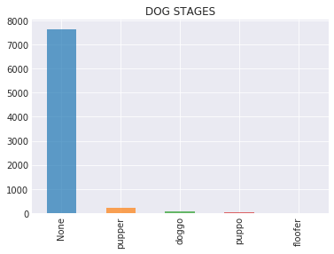

```python
% matplotlib inline
import seaborn as sns
sns.set_style('darkgrid')
stage_max_df.plot.bar( y ='stage_name', alpha = 0.7, title = 'DOG STAGES', legend = '')
```

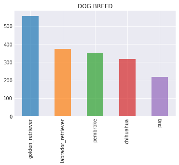

```python
breed_max_df.plot.bar(y =  'p1', alpha= 0.7, legend = '', title = 'DOG BREED')
```